# Week 4: Model Answers

```r
library(languageVariationAndChangeData)
library(dplyr)
```

# Buckeye Data

## Making a sub-table

You can create a table of all grammatical classes like so:

```r
table(buckeye$Gram2)
```

```
       and      justT       mono   nochange         nt       past   semiweak stemchange
     10254         53       9846         24       4162       2458        406         71
      went
       400
```

To get a table with just `past` and `mono`, you can index the table with these names.

```r
gram_tab <- table(buckeye$Gram2)
gram_tab[c("past", "mono")]
```

```
past mono
2458 9846
```

## What words in `justT`

There are a few ways of going about this. The simplest approach involves first taking a subset of the data

```r
justT <- buckeye %>%
            filter(Gram2 == "justT")
```

Now, to see what words are in the `Word` column, you can use the `unique()` function.

```r
unique(justT$Word)
```

```
[1] spent sent  built
1083 Levels: abandoned abhorrent abrupt absent abstract abused accent accept ... zimbalist
```

You could also use the `table()` function, but first you’ll need to drop the empty levels of `Word` (there’s one for every unique word).

```r
# method 1
word_character <- as.character(justT$Word)
table(word_character)
```

```
word_character
built  sent spent
   20    11    22
```

```r
#method 2
word_factor <- factor(justT$Word)
table(word_factor)
```

```
word_factor
built  sent spent
   20    11    22
```

# The SVLR Data

```r
#loading the svlr data
svlr <- read.csv("../../svlr_2015.csv")
```

This section will be very similar to the previous exercises, except it replaces `subset()` with `filter()`, and uses the `%>%` operator. Again, what’s *really* crucial is to keep track of which subsets of the data you want. It’s possible to write R code that will run successfully, but looks at the data the wrong way.

Find out what proportion of Scottish respondents said `tide/tied` were different out of Scottish respondents who were asked about `tide/tied`.

```r
scottish_ay_same <- svlr %>%
                        filter(Scottish == "y",
                               Wordpair == "tide/tied",
                               Response == "same")%>%
                        nrow()
scottish_ay_diff <- svlr %>%
                        filter(Scottish == "y",
                               Wordpair == "tide/tied",
                               Response == "different")%>%
                        nrow()
scottish_ay_diff / (scottish_ay_diff + scottish_ay_same)
```

```
[1] 0.7479675
```

With non-scottish

```r
nonscot_ay_same <- svlr %>%
                        filter(Scottish == "n",
                               Wordpair == "tide/tied",
                               Response == "same")%>%
                        nrow()
nonscot_ay_diff <- svlr %>%
                        filter(Scottish == "n",
                               Wordpair == "tide/tied",
                               Response == "different")%>%
                        nrow()
nonscot_ay_diff / (nonscot_ay_diff + nonscot_ay_same)
```

```
[1] 0.2992701
```

Same as above, but with /ow/ now.

```r
scottish_ow_same <- svlr %>%
                        filter(Scottish == "y",
                               Wordpair == "toad/towed",
                               Response == "same")%>%
                        nrow()
scottish_ow_diff <- svlr %>%
                        filter(Scottish == "y",
                               Wordpair == "toad/towed",
                               Response == "different")%>%
                        nrow()
scottish_ow_diff / (scottish_ow_diff + scottish_ow_same)
```

```
[1] 0.3963964
```

```r
nonscot_ow_same <- svlr %>%
                        filter(Scottish == "n",
                               Wordpair == "toad/towed",
                               Response == "same")%>%
                        nrow()
nonscot_ow_diff <- svlr %>%
                        filter(Scottish == "n",
                               Wordpair == "toad/towed",
                               Response == "different")%>%
                        nrow()
nonscot_ow_diff / (nonscot_ow_diff + nonscot_ow_same)
```

```
[1] 0.4174757
```

# Grouping

```r
  buckeye %>%
    summarise(td = mean(td))
```

| td |
| --- |
| 0.3397413 |

It’s taken the `buckeye` data frame, calculated the mean of the `td` column, and created a new data frame with a column called `td` with the mean value in it.

```r
  buckeye %>%
    group_by(Gram2, PreSeg) %>%
    summarise(td = mean(td))
```

| Gram2 | PreSeg | td |
| --- | --- | --- |
| and | /n/ | 0.07918861 |
| justT | /l/ | 1.00000000 |
| justT | /n/ | 0.57575758 |
| mono | /l/ | 0.84905660 |
| mono | /n/ | 0.43217414 |
| mono | /r/ | 0.90476190 |
| mono | fricative | 0.59459459 |
| mono | sibilant | 0.38144330 |
| mono | stop | 0.62264151 |
| nochange | sibilant | 0.41666667 |

[output cut: 18 more lines]

By putting `group_by()` function before the `summarise()` function, we’ve taken the mean of the `td` column for every for every preceding segment & grammatical class.

If we wanted to get a each speaker’s rate of TD Retention for the regular past, we could do it like so:

```r
buckeye %>%
  filter(Gram2 == "past")%>%
  group_by(Speaker) %>%
  summarise(td = mean(td))
```

| Speaker | td |
| --- | --- |
| s01 | 0.7966102 |
| s02 | 0.6041667 |
| s03 | 0.6000000 |
| s04 | 0.7333333 |
| s05 | 0.8222222 |
| s06 | 0.7619048 |
| s07 | 0.6881720 |
| s08 | 0.7142857 |
| s09 | 0.8148148 |
| s10 | 0.6527778 |

[output cut: 28 more lines]

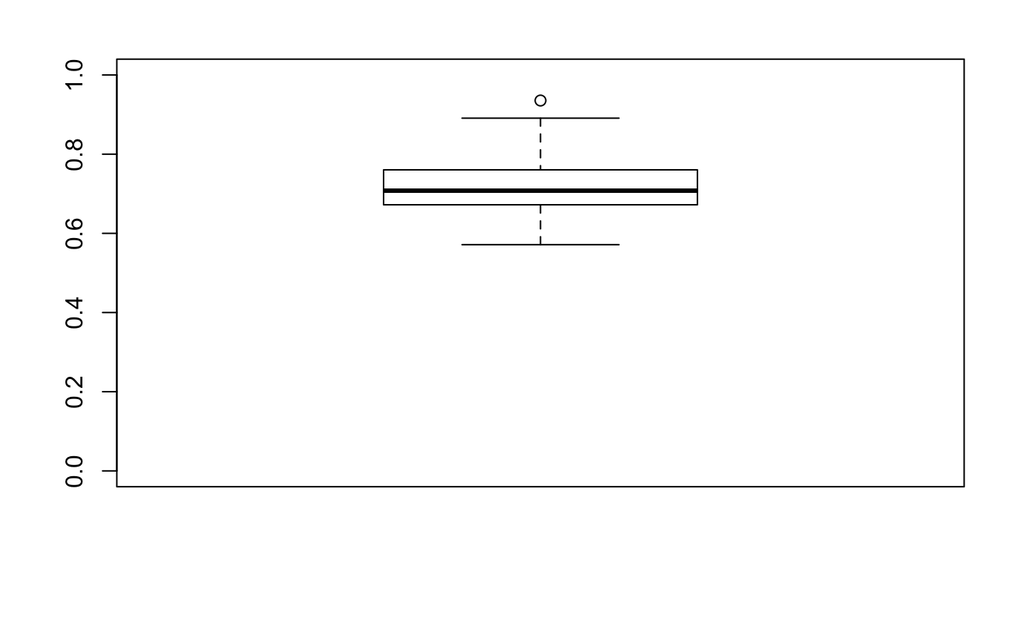

```r
speaker_td <- buckeye %>%
                filter(Gram2 == "past")%>%
                group_by(Speaker) %>%
                summarise(td = mean(td))
boxplot(speaker_td$td, ylim = c(0,1))
```